{% raw %}

{% endraw %} {% raw %}

{% endraw %} {% raw %}

{% endraw %} {% raw %}

```python
from fastai.test_utils import *
```

{% endraw %}

## Annealing

{% raw %}

{% endraw %} {% raw %}

`annealer`[[source]](https://github.com/fastai/fastai/tree/master/fastai/callback/schedule.py#L24)

> `annealer`(**`f`**)

Decorator to make `f` return itself partially applied.

{% endraw %} {% raw %}

{% endraw %}

This is the decorator we will use for all of our scheduling functions, as it transforms a function taking `(start, end, pos)` to something taking `(start, end)` and return a function depending of `pos`.

{% raw %}

{% endraw %} {% raw %}

`sched_lin`[[source]](https://github.com/fastai/fastai/tree/master/fastai/callback/schedule.py#L47)

> `sched_lin`(**`start`**, **`end`**, **`pos`**)

{% endraw %} {% raw %}

`sched_cos`[[source]](https://github.com/fastai/fastai/tree/master/fastai/callback/schedule.py#L48)

> `sched_cos`(**`start`**, **`end`**, **`pos`**)

{% endraw %} {% raw %}

`sched_no`[[source]](https://github.com/fastai/fastai/tree/master/fastai/callback/schedule.py#L49)

> `sched_no`(**`start`**, **`end`**, **`pos`**)

{% endraw %} {% raw %}

`sched_exp`[[source]](https://github.com/fastai/fastai/tree/master/fastai/callback/schedule.py#L50)

> `sched_exp`(**`start`**, **`end`**, **`pos`**)

{% endraw %} {% raw %}

{% endraw %} {% raw %}

```python
annealings = "NO LINEAR COS EXP".split()
p = torch.linspace(0.,1,100)
fns = [SchedNo, SchedLin, SchedCos, SchedExp]
```

{% endraw %} {% raw %}

{% endraw %} {% raw %}

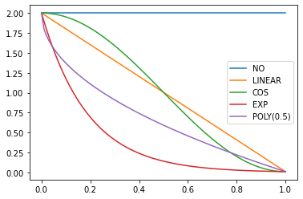

```python
for fn, t in zip(fns, annealings):
    plt.plot(p, [fn(2, 1e-2)(o) for o in p], label=t)
f = SchedPoly(2,1e-2,0.5)
plt.plot(p, [f(o) for o in p], label="POLY(0.5)")
plt.legend();
```

{% endraw %} {% raw %}

`SchedLin`[[source]](https://github.com/fastai/fastai/tree/master/fastai/callback/schedule.py#L52)

> `SchedLin`(**`start`**, **`end`**)

Linear schedule function from `start` to `end`

{% endraw %} {% raw %}

```python
sched = SchedLin(0, 2)
test_eq(L(map(sched, [0., 0.25, 0.5, 0.75, 1.])), [0., 0.5, 1., 1.5, 2.])
```

{% endraw %} {% raw %}

`SchedCos`[[source]](https://github.com/fastai/fastai/tree/master/fastai/callback/schedule.py#L53)

> `SchedCos`(**`start`**, **`end`**)

Cosine schedule function from `start` to `end`

{% endraw %} {% raw %}

```python
sched = SchedCos(0, 2)
test_close(L(map(sched, [0., 0.25, 0.5, 0.75, 1.])), [0., 0.29289, 1., 1.70711, 2.])
```

{% endraw %} {% raw %}

`SchedNo`[[source]](https://github.com/fastai/fastai/tree/master/fastai/callback/schedule.py#L54)

> `SchedNo`(**`start`**, **`end`**)

Constant schedule function with `start` value

{% endraw %} {% raw %}

```python
sched = SchedNo(0, 2)
test_close(L(map(sched, [0., 0.25, 0.5, 0.75, 1.])), [0., 0., 0., 0., 0.])
```

{% endraw %} {% raw %}

`SchedExp`[[source]](https://github.com/fastai/fastai/tree/master/fastai/callback/schedule.py#L55)

> `SchedExp`(**`start`**, **`end`**)

Exponential schedule function from `start` to `end`

{% endraw %} {% raw %}

```python
sched = SchedExp(1, 2)
test_close(L(map(sched, [0., 0.25, 0.5, 0.75, 1.])), [1., 1.18921, 1.41421, 1.68179, 2.])
```

{% endraw %} {% raw %}

`SchedPoly`[[source]](https://github.com/fastai/fastai/tree/master/fastai/callback/schedule.py#L63)

> `SchedPoly`(**`start`**, **`end`**, **`power`**)

Polynomial schedule (of `power`) function from `start` to `end`

{% endraw %} {% raw %}

```python
sched = SchedPoly(0, 2, 2)
test_close(L(map(sched, [0., 0.25, 0.5, 0.75, 1.])), [0., 0.125, 0.5, 1.125, 2.])
```

{% endraw %} {% raw %}

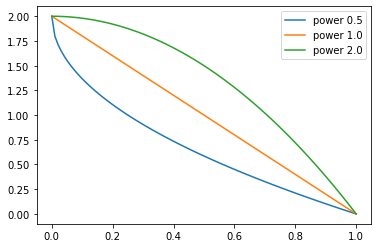

```python
p = torch.linspace(0.,1,100)

pows = [0.5,1.,2.]
for e in pows:
    f = SchedPoly(2, 0, e)
    plt.plot(p, [f(o) for o in p], label=f'power {e}')
plt.legend();
```

{% endraw %} {% raw %}

`combine_scheds`[[source]](https://github.com/fastai/fastai/tree/master/fastai/callback/schedule.py#L69)

> `combine_scheds`(**`pcts`**, **`scheds`**)

Combine `scheds` according to `pcts` in one function

{% endraw %} {% raw %}

{% endraw %}

`pcts` must be a list of positive numbers that add up to 1 and is the same length as `scheds`. The generated function will use `scheds[0]` from 0 to `pcts[0]` then `scheds[1]` from `pcts[0]` to `pcts[0]+pcts[1]` and so forth.

{% raw %}

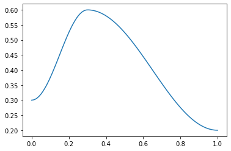

```python
p = torch.linspace(0.,1,100)
f = combine_scheds([0.3,0.7], [SchedCos(0.3,0.6), SchedCos(0.6,0.2)])
plt.plot(p, [f(o) for o in p]);
```

{% endraw %} {% raw %}

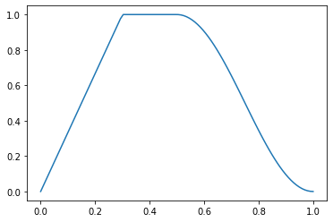

```python
p = torch.linspace(0.,1,100)
f = combine_scheds([0.3,0.2,0.5], [SchedLin(0.,1.), SchedNo(1.,1.), SchedCos(1., 0.)])
plt.plot(p, [f(o) for o in p]);
```

{% endraw %} {% raw %}

`combined_cos`[[source]](https://github.com/fastai/fastai/tree/master/fastai/callback/schedule.py#L83)

> `combined_cos`(**`pct`**, **`start`**, **`middle`**, **`end`**)

Return a scheduler with cosine annealing from `start`→`middle` & `middle`→`end`

{% endraw %} {% raw %}

{% endraw %}

This is a useful helper function for the [1cycle policy](https://sgugger.github.io/the-1cycle-policy.html). `pct` is used for the `start` to `middle` part, `1-pct` for the `middle` to `end`. Handles floats or collection of floats. For example:

{% raw %}

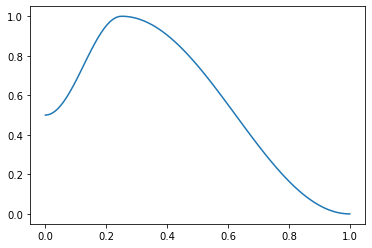

```python
f = combined_cos(0.25,0.5,1.,0.)
plt.plot(p, [f(o) for o in p]);
```

{% endraw %} {% raw %}

`class` `ParamScheduler`[[source]](https://github.com/fastai/fastai/tree/master/fastai/callback/schedule.py#L88)

> `ParamScheduler`(**`scheds`**) :: `Callback`

Schedule hyper-parameters according to `scheds`

{% endraw %} {% raw %}

{% endraw %}

`scheds` is a dictionary with one key for each hyper-parameter you want to schedule, with either a scheduler or a list of schedulers as values (in the second case, the list must have the same length as the the number of parameters groups of the optimizer).

{% raw %}

```python
learn = synth_learner()
sched = {'lr': SchedLin(1e-3, 1e-2)}
learn.fit(1, cbs=ParamScheduler(sched))
n = len(learn.dls.train)
test_close(learn.recorder.hps['lr'], [1e-3 + (1e-2-1e-3) * i/n for i in range(n)])
```

```
[0, 8.36995792388916, 2.77296781539917, '00:00']
```

{% endraw %} {% raw %}

`ParamScheduler.before_fit`[[source]](https://github.com/fastai/fastai/tree/master/fastai/callback/schedule.py#L94)

> `ParamScheduler.before_fit`()

Initialize container for hyper-parameters

{% endraw %} {% raw %}

`ParamScheduler.before_batch`[[source]](https://github.com/fastai/fastai/tree/master/fastai/callback/schedule.py#L95)

> `ParamScheduler.before_batch`()

Set the proper hyper-parameters in the optimizer

{% endraw %} {% raw %}

`ParamScheduler.after_batch`[[source]](https://github.com/fastai/fastai/tree/master/fastai/callback/schedule.py#L100)

> `ParamScheduler.after_batch`()

Record hyper-parameters of this batch

{% endraw %} {% raw %}

`ParamScheduler.after_fit`[[source]](https://github.com/fastai/fastai/tree/master/fastai/callback/schedule.py#L103)

> `ParamScheduler.after_fit`()

Save the hyper-parameters in the recorder if there is one

{% endraw %} {% raw %}

`Learner.fit_one_cycle`[[source]](https://github.com/fastai/fastai/tree/master/fastai/callback/schedule.py#L112)

> `Learner.fit_one_cycle`(**`n_epoch`**, **`lr_max`**=*`None`*, **`div`**=*`25.0`*, **`div_final`**=*`100000.0`*, **`pct_start`**=*`0.25`*, **`wd`**=*`None`*, **`moms`**=*`None`*, **`cbs`**=*`None`*, **`reset_opt`**=*`False`*)

Fit `self.model` for `n_epoch` using the 1cycle policy.

{% endraw %} {% raw %}

{% endraw %}

The 1cycle policy was introduced by Leslie N. Smith et al. in [Super-Convergence: Very Fast Training of Neural Networks Using Large Learning Rates](https://arxiv.org/abs/1708.07120). It schedules the learning rate with a cosine annealing from `lr_max/div` to `lr_max` then `lr_max/div_final` (pass an array to `lr_max` if you want to use differential learning rates) and the momentum with cosine annealing according to the values in `moms`. The first phase takes `pct_start` of the training. You can optionally pass additional `cbs` and `reset_opt`.

{% raw %}

```python
learn = synth_learner(lr=1e-2)
xb,yb = learn.dls.one_batch()
init_loss = learn.loss_func(learn.model(xb), yb)
learn.fit_one_cycle(2)
xb,yb = learn.dls.one_batch()
final_loss = learn.loss_func(learn.model(xb), yb)
assert final_loss < init_loss
```

```
[0, 2.2285118103027344, 0.27008235454559326, '00:00']
[1, 1.069588541984558, 0.0359795056283474, '00:00']
```

{% endraw %} {% raw %}

```python
lrs,moms = learn.recorder.hps['lr'],learn.recorder.hps['mom']
test_close(lrs,  [combined_cos(0.25,1e-2/25,1e-2,1e-7)(i/20) for i in range(20)])
test_close(moms, [combined_cos(0.25,0.95,0.85,0.95)(i/20) for i in range(20)])
```

{% endraw %} {% raw %}

`Recorder.plot_sched`[[source]](https://github.com/fastai/fastai/tree/master/fastai/callback/schedule.py#L124)

> `Recorder.plot_sched`(**`keys`**=*`None`*, **`figsize`**=*`None`*)

{% endraw %} {% raw %}

{% endraw %} {% raw %}

```python
learn = synth_learner()
learn.fit_one_cycle(2)
```

```
[0, 16.201021194458008, 17.18575096130371, '00:00']
[1, 15.065738677978516, 15.73968505859375, '00:00']
```

{% endraw %} {% raw %}

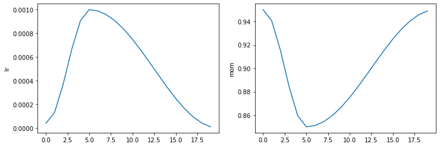

```python
learn.recorder.plot_sched()
```

{% endraw %} {% raw %}

`Learner.fit_flat_cos`[[source]](https://github.com/fastai/fastai/tree/master/fastai/callback/schedule.py#L136)

> `Learner.fit_flat_cos`(**`n_epoch`**, **`lr`**=*`None`*, **`div_final`**=*`100000.0`*, **`pct_start`**=*`0.75`*, **`wd`**=*`None`*, **`cbs`**=*`None`*, **`reset_opt`**=*`False`*)

Fit `self.model` for `n_epoch` at flat `lr` before a cosine annealing.

{% endraw %} {% raw %}

{% endraw %} {% raw %}

```python
learn = synth_learner()
learn.fit_flat_cos(2)
```

```
[0, 13.472519874572754, 14.455650329589844, '00:00']
[1, 11.746286392211914, 10.948918342590332, '00:00']
```

{% endraw %} {% raw %}

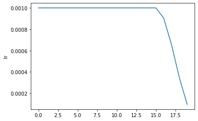

```python
learn.recorder.plot_sched()
```

{% endraw %} {% raw %}

`Learner.fit_sgdr`[[source]](https://github.com/fastai/fastai/tree/master/fastai/callback/schedule.py#L147)

> `Learner.fit_sgdr`(**`n_cycles`**, **`cycle_len`**, **`lr_max`**=*`None`*, **`cycle_mult`**=*`2`*, **`cbs`**=*`None`*, **`reset_opt`**=*`False`*, **`wd`**=*`None`*)

Fit `self.model` for `n_cycles` of `cycle_len` using SGDR.

{% endraw %} {% raw %}

{% endraw %}

This schedule was introduced by Ilya Loshchilov et al. in [SGDR: Stochastic Gradient Descent with Warm Restarts](https://arxiv.org/abs/1608.03983). It consists of `n_cycles` that are cosine annealings from `lr_max` (defaults to the `Learner` lr) to 0, with a length of `cycle_len * cycle_mult**i` for the `i`-th cycle (first one is `cycle_len`-long, then we multiply the length by `cycle_mult` at each epoch). You can optionally pass additional `cbs` and `reset_opt`.

{% raw %}

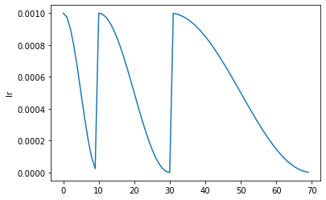

```python
learn = synth_learner()
with learn.no_logging(): learn.fit_sgdr(3, 1)
test_eq(learn.n_epoch, 7)
iters = [k * len(learn.dls.train) for k in [0,1,3,7]]
for i in range(3):
    n = iters[i+1]-iters[i]
    #The start of a cycle can be mixed with the 0 of the previous cycle with rounding errors, so we test at +1
    test_close(learn.recorder.lrs[iters[i]+1:iters[i+1]], [SchedCos(learn.lr, 0)(k/n) for k in range(1,n)])

learn.recorder.plot_sched()
```

{% endraw %} {% raw %}

`Learner.fine_tune`[[source]](https://github.com/fastai/fastai/tree/master/fastai/callback/schedule.py#L160)

> `Learner.fine_tune`(**`epochs`**, **`base_lr`**=*`0.002`*, **`freeze_epochs`**=*`1`*, **`lr_mult`**=*`100`*, **`pct_start`**=*`0.3`*, **`div`**=*`5.0`*, **`lr_max`**=*`None`*, **`div_final`**=*`100000.0`*, **`wd`**=*`None`*, **`moms`**=*`None`*, **`cbs`**=*`None`*, **`reset_opt`**=*`False`*)

Fine tune with `Learner.freeze` for `freeze_epochs`, then with `Learner.unfreeze` for `epochs`, using discriminative LR.

{% endraw %} {% raw %}

{% endraw %} {% raw %}

```python
learn.fine_tune(1)
```

```
[0, 3.950608730316162, 4.651976585388184, '00:00']
[0, 3.3238742351531982, 4.341983795166016, '00:00']
```

{% endraw %} {% raw %}

`class` `LRFinder`[[source]](https://github.com/fastai/fastai/tree/master/fastai/callback/schedule.py#L172)

> `LRFinder`(**`start_lr`**=*`1e-07`*, **`end_lr`**=*`10`*, **`num_it`**=*`100`*, **`stop_div`**=*`True`*) :: `ParamScheduler`

Training with exponentially growing learning rate

{% endraw %} {% raw %}

{% endraw %} {% raw %}

```python
from fastai.vision.all import *
set_seed(99, True)
path = untar_data(URLs.PETS)/'images'

image_files = get_image_files(path)
if sys.platform == "win32" and IN_NOTEBOOK:
    image_files = random.choices(image_files, k=int(len(image_files)/8))
    print("Randomly select 1/8 files in NOTEBOOK on Windows to save time")

# pickle can't serializer lamda function.
def _label_func(x):
    return x[0].isupper()

dls = ImageDataLoaders.from_name_func(
    path, image_files, valid_pct=0.2,
    label_func=_label_func, item_tfms=Resize(224))

learn = vision_learner(dls, resnet18)
learn.fit(1)
learn.opt.state_dict()['state'][1]['grad_avg']
```

| epoch | train_loss | valid_loss | time |
| --- | --- | --- | --- |
| 0 | 0.087492 | 0.022884 | 00:17 |

```
tensor([ 0.0036, -0.0005,  0.0000, -0.0010,  0.0000, -0.0070, -0.0017,  0.0000,
        -0.0009,  0.0000, -0.0130,  0.0042, -0.0012,  0.0000,  0.0125, -0.0044,
         0.0092,  0.0037,  0.0014, -0.0013, -0.0117,  0.0040, -0.0275, -0.0043,
         0.0060, -0.0056, -0.0055,  0.0001,  0.0085,  0.0048, -0.0003, -0.0041,
         0.0004, -0.0058,  0.0052, -0.0049,  0.0000,  0.0078,  0.0000, -0.0128,
        -0.0048,  0.0042,  0.0022,  0.0015,  0.0116,  0.0023,  0.0060,  0.0052,
         0.0000, -0.0050, -0.0148,  0.0080, -0.0045,  0.0021,  0.0008, -0.0147,
         0.0057,  0.0024, -0.0023,  0.0065,  0.0038,  0.0099,  0.0026, -0.0033],
       device='cuda:6')
```

{% endraw %} {% raw %}

```python
with tempfile.TemporaryDirectory() as d:
    learn = synth_learner(path=Path(d))
    init_a,init_b = learn.model.a,learn.model.b
    with learn.no_logging(): learn.fit(20, cbs=LRFinder(num_it=100))
    assert len(learn.recorder.lrs) <= 100
    test_eq(len(learn.recorder.lrs), len(learn.recorder.losses))
    #Check stop if diverge
    if len(learn.recorder.lrs) < 100: assert learn.recorder.losses[-1] > 4 * min(learn.recorder.losses)
    #Test schedule
    test_eq(learn.recorder.lrs, [SchedExp(1e-7, 10)(i/100) for i in range_of(learn.recorder.lrs)])
    #No validation data
    test_eq([len(v) for v in learn.recorder.values], [1 for _ in range_of(learn.recorder.values)])
    #Model loaded back properly
    test_eq(learn.model.a, init_a)
    test_eq(learn.model.b, init_b)
    test_eq(learn.opt.state_dict()['state'], [{}, {}])
```

{% endraw %} {% raw %}

`LRFinder.before_fit`[[source]](https://github.com/fastai/fastai/tree/master/fastai/callback/schedule.py#L181)

> `LRFinder.before_fit`()

Initialize container for hyper-parameters and save the model

{% endraw %} {% raw %}

`LRFinder.before_batch`[[source]](https://github.com/fastai/fastai/tree/master/fastai/callback/schedule.py#L190)

> `LRFinder.before_batch`()

Set the proper hyper-parameters in the optimizer

{% endraw %} {% raw %}

`LRFinder.after_batch`[[source]](https://github.com/fastai/fastai/tree/master/fastai/callback/schedule.py#L192)

> `LRFinder.after_batch`()

Record hyper-parameters of this batch and potentially stop training

{% endraw %} {% raw %}

`LRFinder.before_validate`[[source]](https://github.com/fastai/fastai/tree/master/fastai/callback/schedule.py#L198)

> `LRFinder.before_validate`()

Skip the validation part of training

{% endraw %}

### Suggestion Methods

There are a few methodologies for suggesting a learning rate automatically and these as we will see can further be passed into `lr_find`. Currently four methods are supported, however to write your own it should look like a function that can accept `LRFinder`'s returned `lrs`, `losses`, as well as the `num_it`. Your function should return an `x,y` coordinate that can be plotted, such as below:

```
def myfunc(lrs:list, losses:list, num_it:int) -> tuple(float, tuple(float,int)):
    ...
    return suggestion, (suggestion,loss_idx)
```

If there are any more parameters to be passed in, you should pass in your `func` as a partial and specify them yourself, such as:

```
def myfunc(lrs:list, losses:list, num_it:int, pct_reduction:float) -> tuple(float, tuple(float,int)):
    ...
    return suggestion, (suggestion,loss_idx)
```

```
f = partial(myfunc, pct_reduction=.2)
```

{% raw %}

`valley`[[source]](https://github.com/fastai/fastai/tree/master/fastai/callback/schedule.py#L214)

> `valley`(**`lrs`**:`list`, **`losses`**:`list`, **`num_it`**:`int`)

Suggests a learning rate from the longest valley and returns its index

{% endraw %} {% raw %}

{% endraw %} {% raw %}

```python
doc(valley)
```

{% endraw %}

The `valley` algorithm was developed by [ESRI](https://forums.fast.ai/t/automated-learning-rate-suggester/44199/30) and takes the steepest slope roughly 2/3 through the longest valley in the LR plot, and is also the default for `Learner.lr_find`

{% raw %}

`slide`[[source]](https://github.com/fastai/fastai/tree/master/fastai/callback/schedule.py#L235)

> `slide`(**`lrs`**:`list`, **`losses`**:`list`, **`num_it`**:`int`, **`lr_diff`**:`int`=*`15`*, **`thresh`**:`float`=*`0.005`*, **`adjust_value`**:`float`=*`1.0`*)

Suggests a learning rate following an interval slide rule and returns its index

{% endraw %} {% raw %}

{% endraw %} {% raw %}

```python
doc(slide)
```

{% endraw %}

The `slide` rule is an algorithm developed by Andrew Chang out of Novetta, and is detailed [here](https://forums.fast.ai/t/automated-learning-rate-suggester/44199?u=muellerzr).

{% raw %}

`minimum`[[source]](https://github.com/fastai/fastai/tree/master/fastai/callback/schedule.py#L253)

> `minimum`(**`lrs`**:`list`, **`losses`**:`list`, **`num_it`**:`int`)

Suggests a learning rate one-tenth the minumum before divergance and returns its index

{% endraw %} {% raw %}

{% endraw %} {% raw %}

```python
doc(minimum)
```

{% endraw %} {% raw %}

`steep`[[source]](https://github.com/fastai/fastai/tree/master/fastai/callback/schedule.py#L260)

> `steep`(**`lrs`**:`list`, **`losses`**:`list`, **`num_it`**:`int`)

Suggests a learning rate when the slope is the steepest and returns its index

{% endraw %} {% raw %}

{% endraw %} {% raw %}

```python
doc(steep)
```

{% endraw %} {% raw %}

`Recorder.plot_lr_find`[[source]](https://github.com/fastai/fastai/tree/master/fastai/callback/schedule.py#L268)

> `Recorder.plot_lr_find`(**`skip_end`**=*`5`*, **`return_fig`**=*`True`*, **`suggestions`**=*`None`*, **`nms`**=*`None`*, **`kwargs`)

Plot the result of an LR Finder test (won't work if you didn't do `learn.lr_find()` before)

{% endraw %} {% raw %}

{% endraw %} {% raw %}

{% endraw %} {% raw %}

`Learner.lr_find`[[source]](https://github.com/fastai/fastai/tree/master/fastai/callback/schedule.py#L289)

> `Learner.lr_find`(**`start_lr`**=*`1e-07`*, **`end_lr`**=*`10`*, **`num_it`**=*`100`*, **`stop_div`**=*`True`*, **`show_plot`**=*`True`*, **`suggest_funcs`**=*`valley`*)

Launch a mock training to find a good learning rate and return suggestions based on `suggest_funcs` as a named tuple

{% endraw %} {% raw %}

{% endraw %}

First introduced by Leslie N. Smith in [Cyclical Learning Rates for Training Neural Networks](https://arxiv.org/pdf/1506.01186.pdf), the LR Finder trains the model with exponentially growing learning rates from `start_lr` to `end_lr` for `num_it` and stops in case of divergence (unless `stop_div=False`) then plots the losses vs the learning rates with a log scale.

A variety of learning rate suggestion algorithms can be passed into the function, by default we use the `valley` paradigm.

{% raw %}

```
Minimum/10:	1.58e-01
Steepest point:	1.10e-06
Longest valley:	1.32e-02
Slide interval:	2.51e-05
```

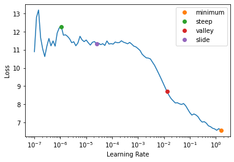

```python
with tempfile.TemporaryDirectory() as d:
    learn = synth_learner(path=Path(d))
    weights_pre_lr_find = L(learn.model.parameters())
    lr_min, lr_steep, lr_valley, lr_slide = learn.lr_find(suggest_funcs=(minimum, steep, valley, slide))
    weights_post_lr_find = L(learn.model.parameters())
test_eq(weights_pre_lr_find, weights_post_lr_find)
print(f"Minimum/10:\t{lr_min:.2e}\nSteepest point:\t{lr_steep:.2e}\nLongest valley:\t{lr_valley:.2e}\nSlide interval:\t{lr_slide:.2e}")
```

{% endraw %}